# 12 Rad sa fajlovima

## 12.1 Podsetnik

- Problemi sa domacim?
- Pogledati **11_zip_moduli_fajlovi.ipynb**

## 12.2 Zadaci

Ovaj cas sastojace se iskljucivo iz resavanja zadataka, kako bi se upoznali sa realnom situacijom u kojoj treba raditi sa fajlovima

### 1

Napisati program koji učitava ime datoteke kao korisnikov unos, a potom ispisuje broj reči u datoteci. U slučaju greške na standardni izlaz za greške ispisati odgovarajuću poruku.

```python
# Resenje
```

### 2

Napisati program koji iz datoteke razno.txt u datoteku palindromi.txt prepisuje sve palindrome. Reč je palindrom ako se isto čita sa leve i sa desne strane bez obzira na veličinu slova. U slučaju greške, na standardni izlaz za greške ispisati odgovarajuću poruku.

```python
# Resenje
```

### 3

Napisati program koji na standardni izlaz ispisuje maksimum brojeva iz datoteke brojevi.txt. U slučaju greške, na standardni izlaz za greške ispisati odgovarajuću poruku.

```python
# Resenje
```

### 4

Kao korisnikov unos unose se ime datoteke i ceo broj k. Napisati program koji na standardni izlaz ispisuje sve linije zadate datoteke čija je dužina veća od k. U slučaju greške, na standardni izlaz za greške ispisati odgovarajuću poruku.

```python
# Resenje
```

### 5

Napisati program koji u datoteci čije se ime navodi kao korisnikov unos određuje liniju maksimalne dužine i ispisuje je na standardni izlaz. Ukoliko ima više takvih linija, ispisati onu koja je leksikografski prva. U slučaju greške, na standardni izlaz za greške ispisati odgovarajuću poruku.

```python
# Resenje
```

### 6

Napisati program koji prebrojava koliko se puta linija datoteke ulaz.txt završava stringom s koji se učitava sa standardnog ulaza. U slučaju greške na standardni izlaz za greške ispisati odgovarajuću poruku.

```
# ulaz.txt
/var/log/apache2/error.log
/var/log/dpkg.log
moj_log.log
/home/korisnik.login
/home/korisnik.log.txt

===========================
# Unos
s = ".log"
===========================
# Izlaz
Broj linija: 3
```

```python
# Resenje
```

### 7

Napisati program koji poredi dve datoteke i ispisuje redni broj linija u kojima se datoteke razlikuju. Imena datoteka se zadaju kao unos korisnika. U slučaju greške, na standardni izlaz za greške ispisati odgovarajuću poruku.

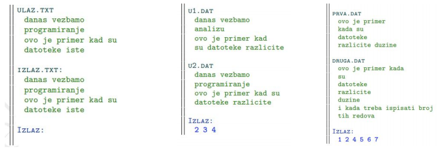

```python
# Resenje
```

### 8

Napisati program koji kao korisnikov unos dobija ime datoteke koja sadrži samo brojeve, pročitati datoteku i sve brojeve učitati u listu. Napisati funkciju koja izbacuje duplikate iz učitane liste, upisati novu listu (bez duplikata) u datoteku bez_duplikata.txt

```python
# Resenje
```